# Chronic Illness and Depression: Prevalence Comorbidity & Costs

### Depression and Use health care Services

First, the marginal effects of depression diagnoses on the use of health care services are investigated. As shown in Table 37 those with depression diagnoses reported, on average 84.4% greater number of Dr. visits in the 12 months preceding the survey, than those without a diagnosis of depression. As the data were significantly right-skewed, the median number of Dr. visits for those with a depression diagnosis was 33.3% greater.

Table 37: Descriptive Statistics of effect of depression on the number of Dr. visits in 12 month period

| Variable | Depression | N | Min | Lower | Median | Mode | Mean | CI | Upper | Max | Range | Total | SD | SE | Skew | Kurtosis |
| --- | --- | --- | --- | --- | --- | --- | --- | --- | --- | --- | --- | --- | --- | --- | --- | --- |
| Visits | Yes | 65774 | 0 | 2 | 4 | 2 | 8.3 | 0.086 | 10 | 76 | 76 | 546140 | 11.28 | 0.044 | 3.34 | 13.60 |
| Visits | No | 270466 | 0 | 1 | 3 | 2 | 4.5 | 0.027 | 5 | 76 | 76 | 1215998 | 7.20 | 0.014 | 5.49 | 41.33 |

Figure 32 graphically displays the two distributions quantitatively described above. The group with depression diagnoses had a higher number of reports of five or more Dr. visits in the year preceding the survey. The reports of Dr. visits among those without a diagnosis had a lower and wider center $Med$ = 3, $\bar{x}$ = 4.5.

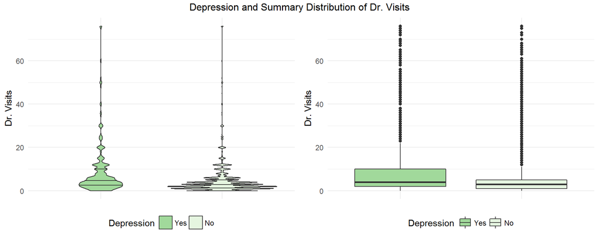

Figure 32: Depression and summary of distribution of Dr. visits

The histogram echos the results from the box plot and adds greater detail of the distribution of reports of five visits or more. In Figure 33, the group with diagnoses of depression reported five Dr. visits or more, as frequently or more frequently than those without a diagnosis (Figure 34).

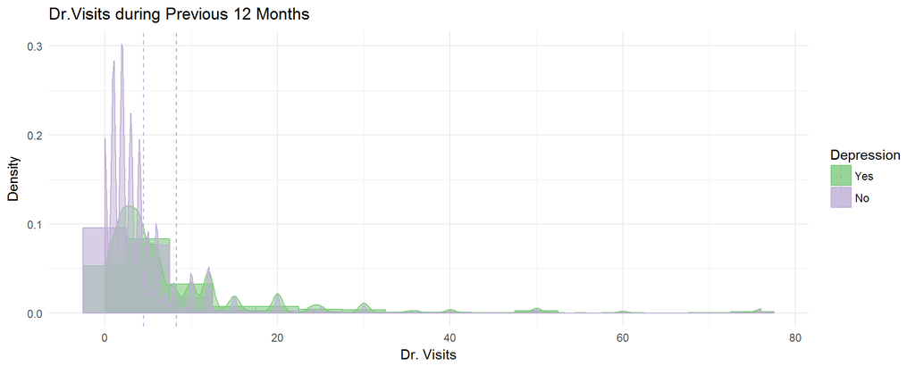

Figure 33: Distribution of Dr. Visits by Diagnosis of Depression

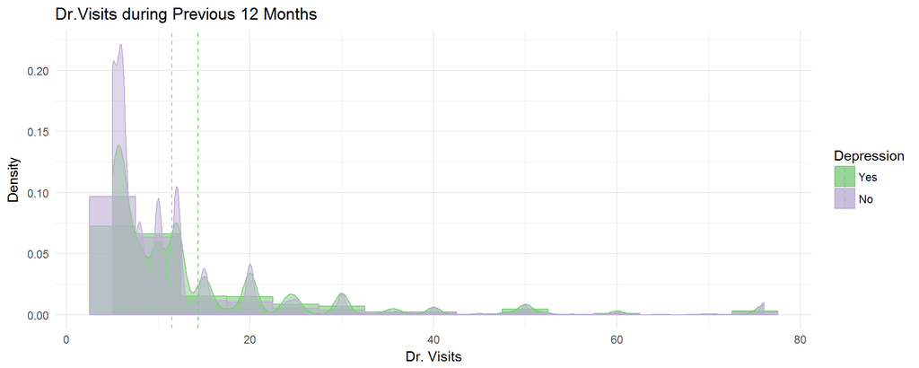

Figure 34: Distribution of five or more Dr. Visits by Diagnosis of Depression

Given the skewness in the data, the non-parametric Mann-Whitney-Wilcoxon test was administered with a significance of $\alpha$ =.05 to determine whether those with a diagnosis of depression visited the Dr. more frequently than those without a diagnosis. The hypotheses were as follows:

$H_0$ Depression has no effect on the number of Dr. Visits between the groups.  
$H_a$ Depression has an effect on the number of Dr. Visits between the groups.

The test indicated that those with depression visited the Dr. more frequently (Mdn = 4), than those without a diagnosis (Mdn = 3), $U$ = 11,655,890,102, $p$ < .001, $r$ = 0.233.

### Chronic Illness and Use health care Services

Considering the marginal effects of diagnoses of one or more chronic conditions, Table 38 shows that those with chronic illness diagnoses reported, on average 97.6% greater number of Dr. visits in the 12 months preceding the survey. The median number of Dr. visits for those with a chronic illness diagnosis was 4 versus those without a diagnosis, 2, a 100% difference.

Table 38: Descriptive Statistics of effect of chronic illness on the number of Dr. visits in a 12 month period

| Variable | Chronic | N | Min | Lower | Median | Mode | Mean | CI | Upper | Max | Range | Total | SD | SE | Skew | Kurtosis |
| --- | --- | --- | --- | --- | --- | --- | --- | --- | --- | --- | --- | --- | --- | --- | --- | --- |
| Visits | Yes | 189549 | 0 | 2 | 4 | 2 | 6.70 | 0.042 | 7 | 76 | 76 | 1269195 | 9.34 | 0.021 | 4.06 | 21.28 |
| Visits | No | 148074 | 0 | 1 | 2 | 1 | 3.39 | 0.032 | 4 | 76 | 76 | 501401 | 6.27 | 0.016 | 6.99 | 65.85 |

As indicated in Figure 35, the group with chronic illness diagnoses had a higher number of reports of five or more Dr. visits in the year preceding the survey. The reports of Dr. visits among those without a diagnosis had a lower and wider center of around 2 visits for the year.

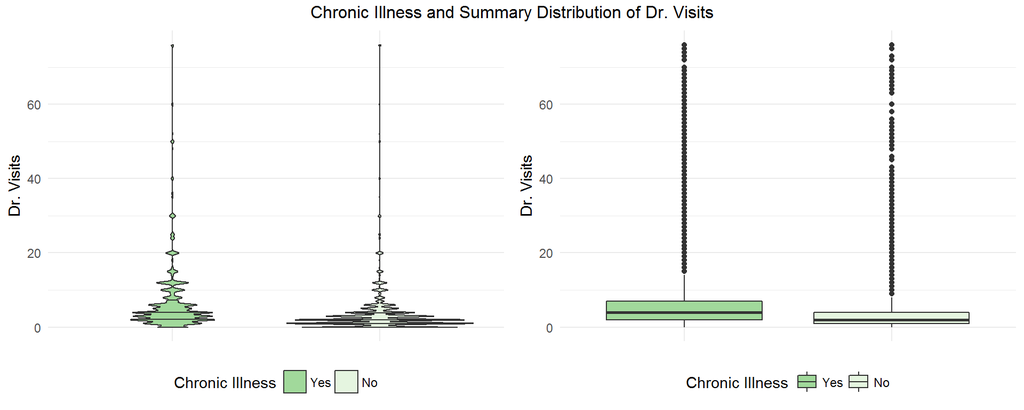

Figure 35: Chronic Illness and Summary of Distribution of Dr. Visits

Figure 36, visually represents the quantitative results above. The group with diagnoses of chronic illness reported five or more Dr. visits, as frequently or more frequently than those without a diagnosis (Figure 37).

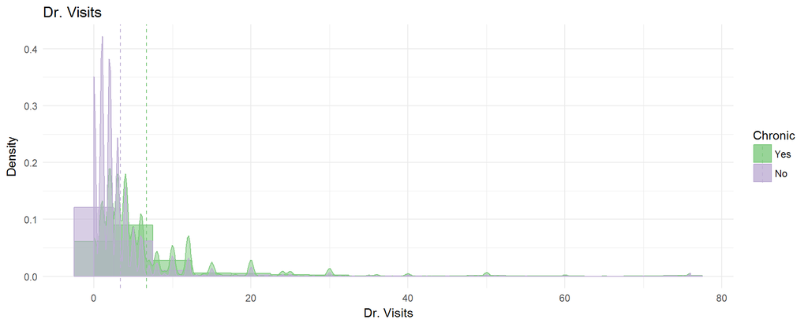

Figure 36: Distribution of Dr. Visits by Diagnosis of Chronic Illness

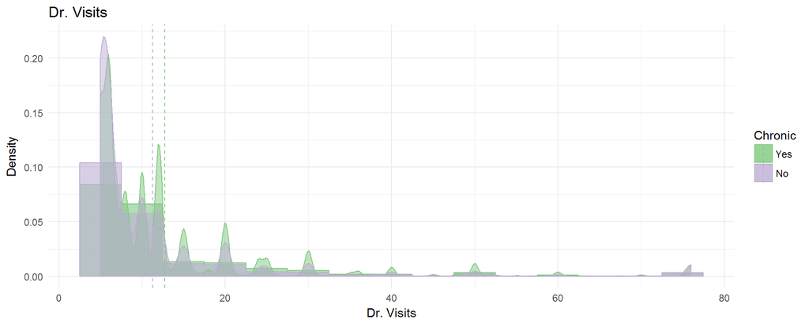

Figure 37: Distribution of five or more Dr. Visits by Diagnosis of Chronic Illness

Mann-Whitney-Wilcoxon test was administered with a significance of $\alpha$ =.05 to determine whether those with a diagnosis of chronic illness visited the Dr. more frequently than those without a diagnosis. The hypotheses were as follows:

$H_0$ Chronic Illness has no effect on the number of Dr. Visits.  
$H_a$ Chronic Illness has an effect on the number of Dr. Visits.

The test indicated that those with chronic illness visited the Dr. more frequently (Mdn = 4), than those without a diagnosis (Mdn = 2), $U$ = 19,515,475,116, $p$ < .001, $r$ = 0.299.

### The Effect of Depression and Chronic Illness on the Use of Health Services

Table 39 reveals significant differences in mean number of Dr. visits reported by diagnosis scenario. Naturally, those with neither diagnosis reported the lowest number of Dr. visits; however, the number increased approximately 80.2% for those having either a diagnosis of depression or a diagnosis of one or more chronic conditions. Those having both diagnoses visited the doctor 68.5% more often than those with either a diagnosis of depression, or one or more chronic conditions.

Table 39: Descriptive Statistics of Dr. Visits by Chronic Disease and Depression Diagnoses

| Variable | DepressionChronic | N | Min | Lower | Median | Mode | Mean | CI | Upper | Max | Range | Total | SD | SE | Skew | Kurtosis |
| --- | --- | --- | --- | --- | --- | --- | --- | --- | --- | --- | --- | --- | --- | --- | --- | --- |
| Visits | Yes.Yes | 47670 | 0 | 3 | 5 | 4 | 9.35 | 0.108 | 12 | 76 | 76 | 445623 | 11.98 | 0.055 | 3.09 | 11.45 |
| Visits | No.Yes | 141080 | 0 | 2 | 4 | 2 | 5.80 | 0.042 | 6 | 76 | 76 | 817602 | 8.05 | 0.021 | 4.59 | 28.65 |
| Visits | Yes.No | 18104 | 0 | 2 | 3 | 2 | 5.55 | 0.125 | 6 | 76 | 76 | 100517 | 8.58 | 0.064 | 4.48 | 26.15 |
| Visits | No.No | 129386 | 0 | 1 | 2 | 1 | 3.08 | 0.032 | 3 | 76 | 76 | 398396 | 5.81 | 0.016 | 7.82 | 82.67 |

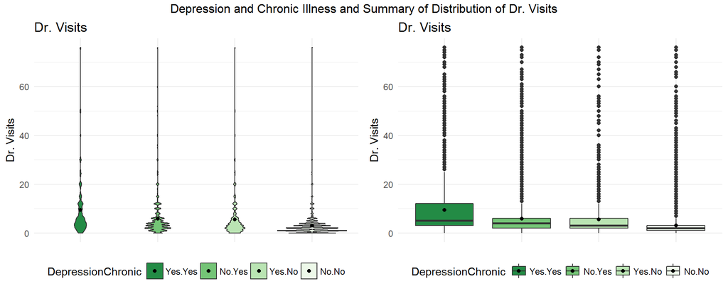

Figure 38: Distribution Summary of Reports of Dr. Visits by Diagnosis of Chronic Illness & Depression

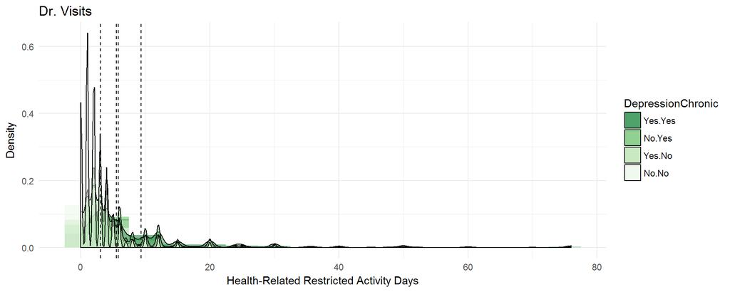

Figure 39: Distribution of Dr. Visits by Diagnosis of Chronic Illness and Depression

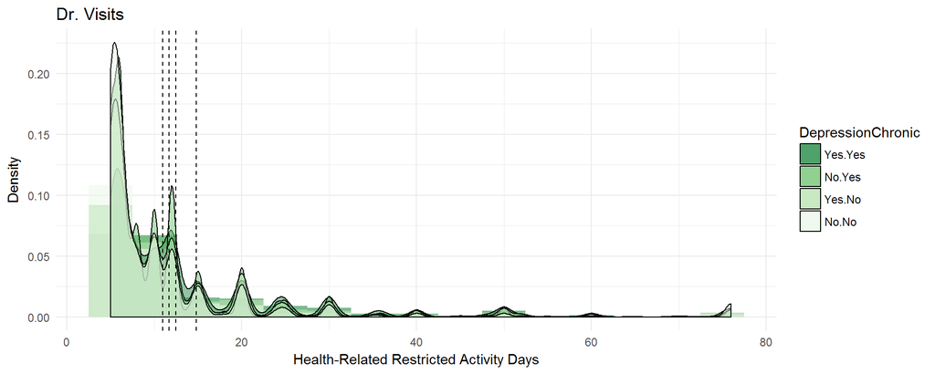

Figure 40: Distribution of Dr. Visits by Diagnosis of Chronic Illness and Depression

The white in Figure 40 represents the reports of those with neither diagnosis and the dark green end of the spectrum symbolizes the reports of those with both diagnoses. The left side is dominated by light colors, representing the reports of doctors visits among those with neither diagnosis, or just one. Moving right, the graph grows darker with reports of higher numbers of doctor visits among those with one, or both diagnoses.

Figure 41 illustrates how the effect of chronic illness on doctor visits varies with depression.

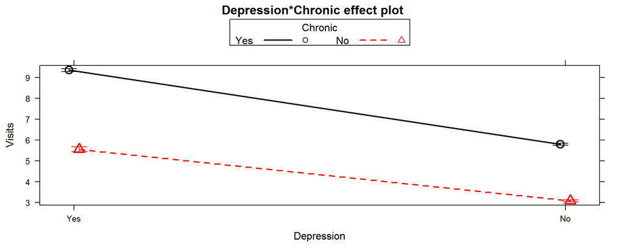

Figure 41: Effect of chronic illness on user of health services, with and without concurrent depression

$H_0$ The effect of chronic illness on the use of health services is not affected by the presence of depression $H_a$ The effect of chronic illness on the use of health services is affected by the presence of depression

As expected, there was a significant difference in the number of Dr. visits among the four scenarios, $X^2$ = 47,536.16, $p$ < .001, $df$ = 3. To determine which scenario had the greatest effect on use of health services, several pairwise post hoc Mann-Whitney-Wilcoxon tests were administered at a significance of $\alpha$ =.05, under the following hypotheses.

$H_0$ There is no difference in the number of doctor visits between those without diagnoses of chronic illness and depression and those with a diagnosis of depression, without concurrent chronic illness  
$H_0$ There is no difference in the number of doctor visits between those with a diagnosis of depression, without concurrent chronic illness and those with a diagnosis of chronic illness, without concurrent depression  
$H_0$ There is no difference in the number of doctor visits between those with a diagnosis of chronic illness, without concurrent depression and those with both diagnoses  
$H_a$ There is a difference in the number of doctor visits between those without diagnoses of chronic illness and depression and those with a diagnosis of depression, without concurrent chronic illness  
$H_a$ There is a difference in the number of doctor visits between those with a diagnosis of depression, without concurrent chronic illness and those with a diagnosis of chronic illness, without concurrent depression  
$H_a$ There is a difference in the number of doctor visits between those with a diagnosis of chronic illness, without concurrent depression and those with both diagnoses

The results of the tests are summarized in Table 40.

Table 40: Pairwise Mann-Whitney-Wilcoxon tests of depression and chronic illness on use of health services

| Test | Group A A.Depression | Group A A.Chronic | Group B B.Depression | Group B B.Chronic | X2 | p | Estimate | Lower_CI | Upper_CI | Effect |
| --- | --- | --- | --- | --- | --- | --- | --- | --- | --- | --- |
| 1 | Yes | Yes | No | Yes | 4171778277 | 0 | 1.9999310 | 1.9999660 | 1.9999840 | 0.1852755 |
| 2 | No | Yes | Yes | No | 1383938395 | 0 | 0.0000202 | 0.0000136 | 0.0000278 | 0.0728442 |
| 3 | Yes | No | No | No | 1507185966 | 0 | 1.0000606 | 1.0000656 | 1.0000184 | 0.2201032 |

Which chronic diseases have the greatest impact on the use of health care services? The following bar chart depicts the mean number of doctor visits during the 12 months preceding the survey, by condition.

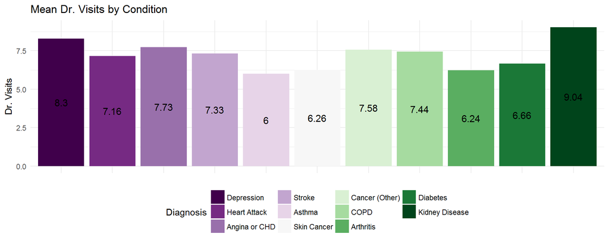

Figure 42: Dr. visits during previous 12 months, by chronic condition

Of the ten chronic diseases reported, depression was second to kidney disease in reports of doctor visits.

In closing, concurrent depression and chronic illness had a drastic impact on use of health services, $X^2$ = 4,171,778,277, $p$ < .001, effect size = 0.19. Those with concurrent diagnoses used health care services 61.2% more often than those with a single diagnosis of either depression, or one or more chronic illnesses, and 204% more often than those without diagnoses of chronic illness or depression.